# splicelogic vs Swan genes on the Glinos PTBP1 dataset, FDR < 0.05

#### NECTIN2 (ENSG00000130202)

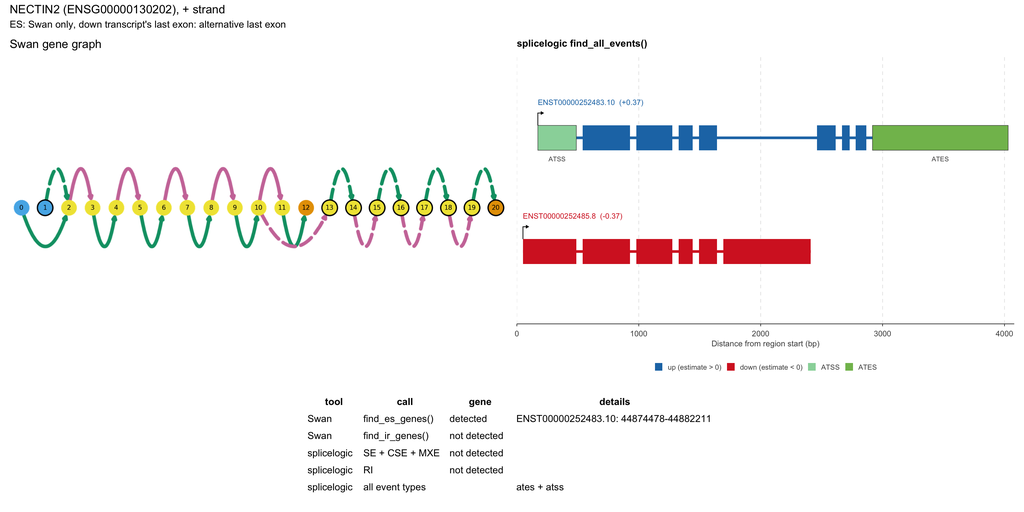

`sg.find_es_genes().query("gid == 'ENSG00000130202'")`

| gid | tid | edge_id |
| --- | --- | --- |
| ENSG00000130202 | ENST00000252483.10 | 10873 |

`sg.find_ir_genes().query("gid == 'ENSG00000130202'")`

**0 rows**: the gene is not in this output

`find_all_events(sl_pre) |> filter(gene_id == "ENSG00000130202.10", event_type %in% c("se", "cse", "mxe"))`

**0 rows**: the gene is not in this output

`find_all_events(sl_pre) |> filter(gene_id == "ENSG00000130202.10", event_type %in% c("ri"))`

**0 rows**: the gene is not in this output

`find_all_events(sl_pre) |> filter(gene_id == "ENSG00000130202.10", event_type %in% c("atss", "ates"))`

| seqnames | start | end | strand | gene_id | tx_id | exon_rank | estimate | event_type | event_tx_id | event_estimate |
| --- | --- | --- | --- | --- | --- | --- | --- | --- | --- | --- |
| chr19 | 44846297 | 44846613 | + | ENSG00000130202.10 | ENST00000252483.10 | 1 | 0.365 | atss | ENST00000252485.8 | -0.365 |
| chr19 | 44888110 | 44889223 | + | ENSG00000130202.10 | ENST00000252483.10 | 9 | 0.365 | ates | ENST00000252485.8 | -0.365 |

#### OIP5-AS1 (ENSG00000247556)

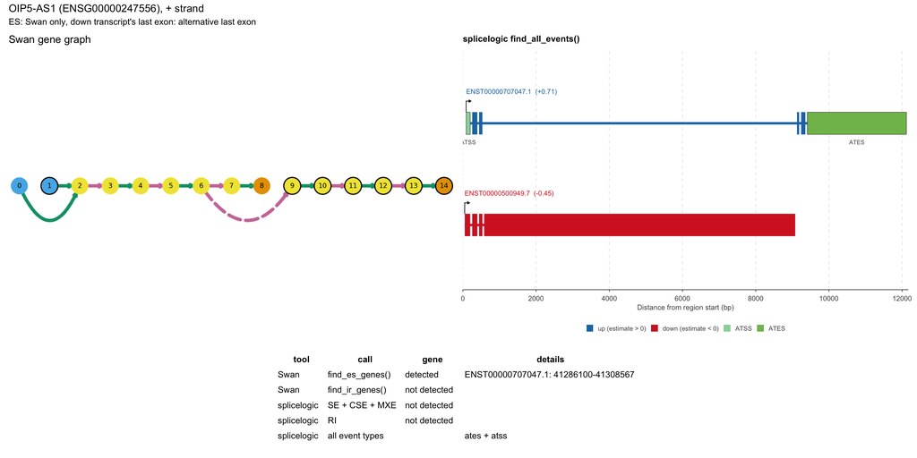

`sg.find_es_genes().query("gid == 'ENSG00000247556'")`

| gid | tid | edge_id |
| --- | --- | --- |
| ENSG00000247556 | ENST00000707047.1 | 13455 |

`sg.find_ir_genes().query("gid == 'ENSG00000247556'")`

**0 rows**: the gene is not in this output

`find_all_events(sl_pre) |> filter(gene_id == "ENSG00000247556.8", event_type %in% c("se", "cse", "mxe"))`

**0 rows**: the gene is not in this output

`find_all_events(sl_pre) |> filter(gene_id == "ENSG00000247556.8", event_type %in% c("ri"))`

**0 rows**: the gene is not in this output

`find_all_events(sl_pre) |> filter(gene_id == "ENSG00000247556.8", event_type %in% c("atss", "ates"))`

| seqnames | start | end | strand | gene_id | tx_id | exon_rank | estimate | event_type | event_tx_id | event_estimate |
| --- | --- | --- | --- | --- | --- | --- | --- | --- | --- | --- |
| chr15 | 41283997 | 41284110 | + | ENSG00000247556.8 | ENST00000707047.1 | 1 | 0.708 | atss | ENST00000500949.7 | -0.447 |
| chr15 | 41319685 | 41322392 | + | ENSG00000247556.8 | ENST00000707047.1 | 6 | 0.708 | ates | ENST00000500949.7 | -0.447 |

#### PRSS23 (ENSG00000150687)

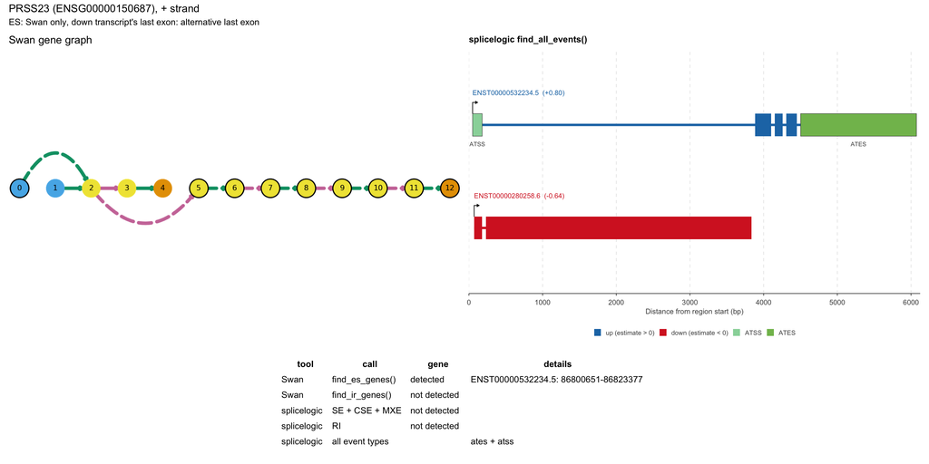

`sg.find_es_genes().query("gid == 'ENSG00000150687'")`

| gid | tid | edge_id |
| --- | --- | --- |
| ENSG00000150687 | ENST00000532234.5 | 12845 |

`sg.find_ir_genes().query("gid == 'ENSG00000150687'")`

**0 rows**: the gene is not in this output

`find_all_events(sl_pre) |> filter(gene_id == "ENSG00000150687.12", event_type %in% c("se", "cse", "mxe"))`

**0 rows**: the gene is not in this output

`find_all_events(sl_pre) |> filter(gene_id == "ENSG00000150687.12", event_type %in% c("ri"))`

**0 rows**: the gene is not in this output

`find_all_events(sl_pre) |> filter(gene_id == "ENSG00000150687.12", event_type %in% c("atss", "ates"))`

| seqnames | start | end | strand | gene_id | tx_id | exon_rank | estimate | event_type | event_tx_id | event_estimate |
| --- | --- | --- | --- | --- | --- | --- | --- | --- | --- | --- |
| chr11 | 86800521 | 86800651 | + | ENSG00000150687.12 | ENST00000532234.5 | 1 | 0.795 | atss | ENST00000280258.6 | -0.635 |
| chr11 | 86951216 | 86952788 | + | ENSG00000150687.12 | ENST00000532234.5 | 5 | 0.795 | ates | ENST00000280258.6 | -0.635 |

#### SARS1 (ENSG00000031698)

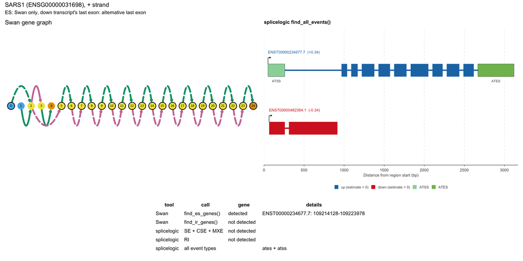

`sg.find_es_genes().query("gid == 'ENSG00000031698'")`

| gid | tid | edge_id |
| --- | --- | --- |
| ENSG00000031698 | ENST00000234677.7 | 10837 |

`sg.find_ir_genes().query("gid == 'ENSG00000031698'")`

**0 rows**: the gene is not in this output

`find_all_events(sl_pre) |> filter(gene_id == "ENSG00000031698.13", event_type %in% c("se", "cse", "mxe"))`

**0 rows**: the gene is not in this output

`find_all_events(sl_pre) |> filter(gene_id == "ENSG00000031698.13", event_type %in% c("ri"))`

**0 rows**: the gene is not in this output

`find_all_events(sl_pre) |> filter(gene_id == "ENSG00000031698.13", event_type %in% c("atss", "ates"))`

| seqnames | start | end | strand | gene_id | tx_id | exon_rank | estimate | event_type | event_tx_id | event_estimate |
| --- | --- | --- | --- | --- | --- | --- | --- | --- | --- | --- |
| chr1 | 109213918 | 109214128 | + | ENSG00000031698.13 | ENST00000234677.7 | 1 | 0.344 | atss | ENST00000482384.1 | -0.344 |
| chr1 | 109237731 | 109238182 | + | ENSG00000031698.13 | ENST00000234677.7 | 11 | 0.344 | ates | ENST00000482384.1 | -0.344 |

#### TRIB2 (ENSG00000071575)

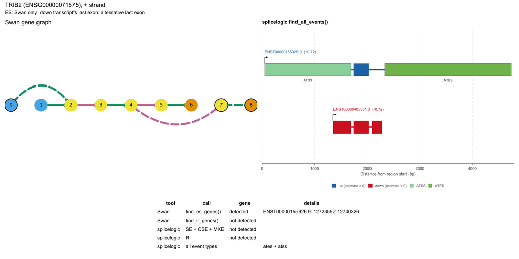

`sg.find_es_genes().query("gid == 'ENSG00000071575'")`

| gid | tid | edge_id |
| --- | --- | --- |
| ENSG00000071575 | ENST00000155926.9 | 10714 |

`sg.find_ir_genes().query("gid == 'ENSG00000071575'")`

**0 rows**: the gene is not in this output

`find_all_events(sl_pre) |> filter(gene_id == "ENSG00000071575.12", event_type %in% c("se", "cse", "mxe"))`

**0 rows**: the gene is not in this output

`find_all_events(sl_pre) |> filter(gene_id == "ENSG00000071575.12", event_type %in% c("ri"))`

**0 rows**: the gene is not in this output

`find_all_events(sl_pre) |> filter(gene_id == "ENSG00000071575.12", event_type %in% c("atss", "ates"))`

| seqnames | start | end | strand | gene_id | tx_id | exon_rank | estimate | event_type | event_tx_id | event_estimate |
| --- | --- | --- | --- | --- | --- | --- | --- | --- | --- | --- |
| chr2 | 12716936 | 12718577 | + | ENSG00000071575.12 | ENST00000155926.9 | 1 | 0.722 | atss | ENST00000405331.3 | -0.722 |
| chr2 | 12740326 | 12742734 | + | ENSG00000071575.12 | ENST00000155926.9 | 3 | 0.722 | ates | ENST00000405331.3 | -0.722 |

#### TSEN15 (ENSG00000198860)

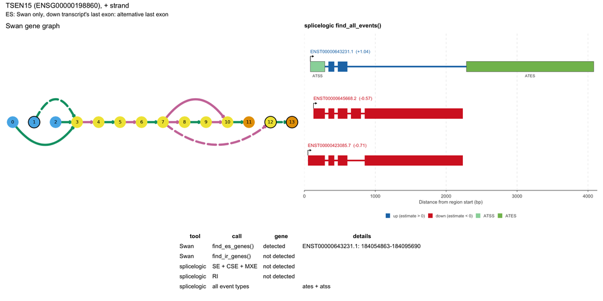

`sg.find_es_genes().query("gid == 'ENSG00000198860'")`

| gid | tid | edge_id |
| --- | --- | --- |
| ENSG00000198860 | ENST00000643231.1 | 13132 |
| ENSG00000198860 | ENST00000643231.1 | 13132 |

`sg.find_ir_genes().query("gid == 'ENSG00000198860'")`

**0 rows**: the gene is not in this output

`find_all_events(sl_pre) |> filter(gene_id == "ENSG00000198860.14", event_type %in% c("se", "cse", "mxe"))`

**0 rows**: the gene is not in this output

`find_all_events(sl_pre) |> filter(gene_id == "ENSG00000198860.14", event_type %in% c("ri"))`

**0 rows**: the gene is not in this output

`find_all_events(sl_pre) |> filter(gene_id == "ENSG00000198860.14", event_type %in% c("atss", "ates"))`

| seqnames | start | end | strand | gene_id | tx_id | exon_rank | estimate | event_type | event_tx_id | event_estimate |
| --- | --- | --- | --- | --- | --- | --- | --- | --- | --- | --- |
| chr1 | 184051686 | 184051890 | + | ENSG00000198860.14 | ENST00000643231.1 | 1 | 1.042 | atss | ENST00000423085.7 | -0.709 |
| chr1 | 184051686 | 184051890 | + | ENSG00000198860.14 | ENST00000643231.1 | 1 | 1.042 | atss | ENST00000645668.2 | -0.575 |
| chr1 | 184095690 | 184097485 | + | ENSG00000198860.14 | ENST00000643231.1 | 4 | 1.042 | ates | ENST00000423085.7 | -0.709 |
| chr1 | 184095690 | 184097485 | + | ENSG00000198860.14 | ENST00000643231.1 | 4 | 1.042 | ates | ENST00000645668.2 | -0.575 |

#### TTC17 (ENSG00000052841)

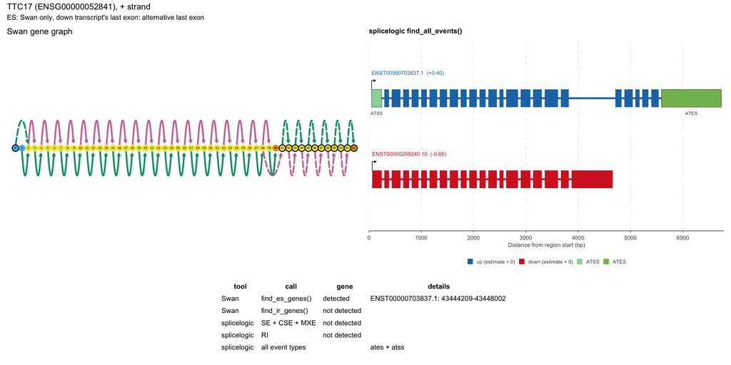

`sg.find_es_genes().query("gid == 'ENSG00000052841'")`

| gid | tid | edge_id |
| --- | --- | --- |
| ENSG00000052841 | ENST00000703837.1 | 13437 |

`sg.find_ir_genes().query("gid == 'ENSG00000052841'")`

**0 rows**: the gene is not in this output

`find_all_events(sl_pre) |> filter(gene_id == "ENSG00000052841.16", event_type %in% c("se", "cse", "mxe"))`

**0 rows**: the gene is not in this output

`find_all_events(sl_pre) |> filter(gene_id == "ENSG00000052841.16", event_type %in% c("ri"))`

**0 rows**: the gene is not in this output

`find_all_events(sl_pre) |> filter(gene_id == "ENSG00000052841.16", event_type %in% c("atss", "ates"))`

| seqnames | start | end | strand | gene_id | tx_id | exon_rank | estimate | event_type | event_tx_id | event_estimate |
| --- | --- | --- | --- | --- | --- | --- | --- | --- | --- | --- |
| chr11 | 43358920 | 43359113 | + | ENSG00000052841.16 | ENST00000703837.1 | 1 | 0.401 | atss | ENST00000299240.10 | -0.66 |
| chr11 | 43493773 | 43494922 | + | ENSG00000052841.16 | ENST00000703837.1 | 25 | 0.401 | ates | ENST00000299240.10 | -0.66 |

#### VTI1A (ENSG00000151532)

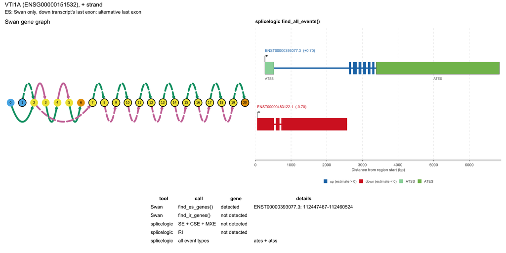

`sg.find_es_genes().query("gid == 'ENSG00000151532'")`

| gid | tid | edge_id |
| --- | --- | --- |
| ENSG00000151532 | ENST00000393077.3 | 12131 |
| ENSG00000151532 | ENST00000393077.3 | 12131 |

`sg.find_ir_genes().query("gid == 'ENSG00000151532'")`

**0 rows**: the gene is not in this output

`find_all_events(sl_pre) |> filter(gene_id == "ENSG00000151532.15", event_type %in% c("se", "cse", "mxe"))`

**0 rows**: the gene is not in this output

`find_all_events(sl_pre) |> filter(gene_id == "ENSG00000151532.15", event_type %in% c("ri"))`

**0 rows**: the gene is not in this output

`find_all_events(sl_pre) |> filter(gene_id == "ENSG00000151532.15", event_type %in% c("atss", "ates"))`

| seqnames | start | end | strand | gene_id | tx_id | exon_rank | estimate | event_type | event_tx_id | event_estimate |
| --- | --- | --- | --- | --- | --- | --- | --- | --- | --- | --- |
| chr10 | 112447215 | 112447467 | + | ENSG00000151532.15 | ENST00000393077.3 | 1 | 0.696 | atss | ENST00000483122.1 | -0.696 |
| chr10 | 112815290 | 112818744 | + | ENSG00000151532.15 | ENST00000393077.3 | 8 | 0.696 | ates | ENST00000483122.1 | -0.696 |

#### ZNF226 (ENSG00000167380)

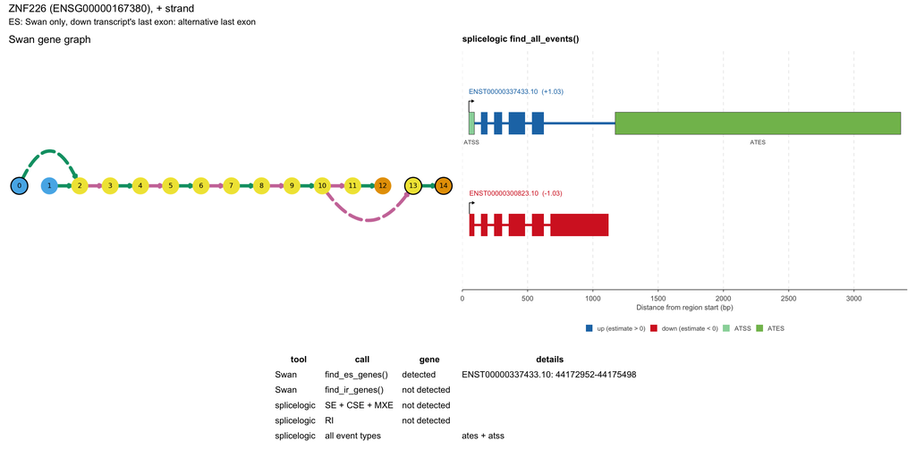

`sg.find_es_genes().query("gid == 'ENSG00000167380'")`

| gid | tid | edge_id |
| --- | --- | --- |
| ENSG00000167380 | ENST00000337433.10 | 11510 |

`sg.find_ir_genes().query("gid == 'ENSG00000167380'")`

**0 rows**: the gene is not in this output

`find_all_events(sl_pre) |> filter(gene_id == "ENSG00000167380.17", event_type %in% c("se", "cse", "mxe"))`

**0 rows**: the gene is not in this output

`find_all_events(sl_pre) |> filter(gene_id == "ENSG00000167380.17", event_type %in% c("ri"))`

**0 rows**: the gene is not in this output

`find_all_events(sl_pre) |> filter(gene_id == "ENSG00000167380.17", event_type %in% c("atss", "ates"))`

| seqnames | start | end | strand | gene_id | tx_id | exon_rank | estimate | event_type | event_tx_id | event_estimate |
| --- | --- | --- | --- | --- | --- | --- | --- | --- | --- | --- |
| chr19 | 44165100 | 44165142 | + | ENSG00000167380.17 | ENST00000337433.10 | 1 | 1.033 | atss | ENST00000300823.10 | -1.033 |
| chr19 | 44175498 | 44177685 | + | ENSG00000167380.17 | ENST00000337433.10 | 6 | 1.033 | ates | ENST00000300823.10 | -1.033 |

#### ZNF451 (ENSG00000112200)

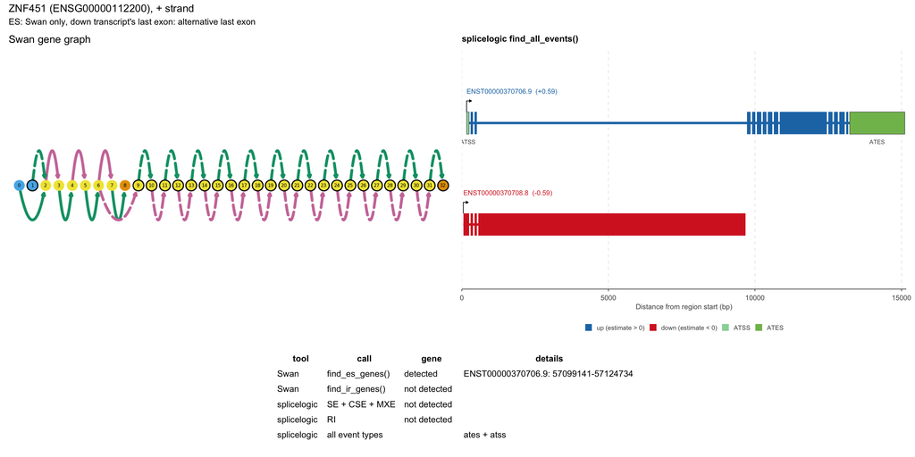

`sg.find_es_genes().query("gid == 'ENSG00000112200'")`

| gid | tid | edge_id |
| --- | --- | --- |
| ENSG00000112200 | ENST00000370706.9 | 11837 |

`sg.find_ir_genes().query("gid == 'ENSG00000112200'")`

**0 rows**: the gene is not in this output

`find_all_events(sl_pre) |> filter(gene_id == "ENSG00000112200.17", event_type %in% c("se", "cse", "mxe"))`

**0 rows**: the gene is not in this output

`find_all_events(sl_pre) |> filter(gene_id == "ENSG00000112200.17", event_type %in% c("ri"))`

**0 rows**: the gene is not in this output

`find_all_events(sl_pre) |> filter(gene_id == "ENSG00000112200.17", event_type %in% c("atss", "ates"))`

| seqnames | start | end | strand | gene_id | tx_id | exon_rank | estimate | event_type | event_tx_id | event_estimate |
| --- | --- | --- | --- | --- | --- | --- | --- | --- | --- | --- |
| chr6 | 57090188 | 57090274 | + | ENSG00000112200.17 | ENST00000370706.9 | 1 | 0.593 | atss | ENST00000370708.8 | -0.593 |
| chr6 | 57168423 | 57170305 | + | ENSG00000112200.17 | ENST00000370706.9 | 15 | 0.593 | ates | ENST00000370708.8 | -0.593 |

## 9. Summary

splicelogic and Swan side by side: what they have in common, where they differ, the genes both call, and every plus-strand gene they do not agree on, with why. The numbers in this section are computed from the sections above; section 10 has the same numbers in tables.

```r
# the plus-strand gene lists compared in section 4
plus_es <- gene_match[gene_match$strand == "+" & gene_match$event == "ES", ]
plus_ir <- gene_match[gene_match$strand == "+" & gene_match$event == "IR", ]
n_both <- function(d) sum(d$status == "both")
n_swan <- function(d) sum(d$swan)
n_sl   <- function(d) sum(d$splicelogic)
both_any  <- union(plus_es$gid[plus_es$status == "both"],
                   plus_ir$gid[plus_ir$status == "both"])
subset_es <- es_variants[es_variants$event == "+ ATSS / ATES subset" &
                           es_variants$strand == "+", ]
minus <- gene_match[gene_match$strand == "-", ]

# the plus-strand genes that do not match, by reason (section 6)
by_reason <- function(event, status, reason) {
  plus_mismatch[plus_mismatch$event == event &
                  plus_mismatch$status == status &
                  plus_mismatch$reason == reason, ]
}
mm_sl_es   <- by_reason("ES", "splicelogic only",
                        "skipping intron also in a down transcript")
mm_sl_ir   <- by_reason("IR", "splicelogic only",
                        "retaining exon also in a down transcript")
mm_first   <- by_reason("ES", "Swan only",
                        "down transcript's first exon: alternative first exon")
mm_last    <- by_reason("ES", "Swan only",
                        "down transcript's last exon: alternative last exon")
mm_only_up <- by_reason("ES", "Swan only", "exon inside only in up transcripts")
# and the one the ATSS / ATES subset adds (section 7)
mm_subset  <- subset_plus[!subset_plus$gid %in% plus_mismatch$gid, ]

# every plus-strand mismatch is in one of these groups
stopifnot(nrow(mm_sl_es) + nrow(mm_sl_ir) + nrow(mm_first) + nrow(mm_last) +
            nrow(mm_only_up) == nrow(plus_mismatch))

names_of <- function(d) paste(sort(unique(d$gene_name)), collapse = ", ")
```

### What is the same

- **The same question.** Both compare two groups of transcripts of a gene and report what one group does that the other does not. Here the down transcripts are Swan’s annotation and the up transcripts its transcriptome, so both report what the up transcripts do relative to the down ones.
- **The same kind of input.** Both work from whole transcript structures (each transcript’s exons: a GTF for Swan, a `GRanges` for splicelogic), not from junction or exon counts.
- **The same two event types.** Swan’s exon skipping (ES) is splicelogic’s SE + CSE + MXE, and Swan’s intron retention (IR) is splicelogic’s RI. On the plus strand they call the same 80 ES genes and the same 12 IR genes (below).
- **The same answer for alternative first / last exons.** When Swan’s ES is a down transcript’s first or last exon, skipped, splicelogic calls an ATSS or ATES for the same up transcript, the same down transcript and the same intron: 30 of 30 Swan rows (section 7).
- **Both draw a gene.** Swan as a graph of its splice sites, with the edges found only in up transcripts dashed; splicelogic as its transcripts, with each event marked (section 8).

### What is different

- **Event types.** Swan calls 2, ES and IR, with `find_es_genes()` and `find_ir_genes()`; splicelogic calls 11. Swan has no call for:
  - IE, CIE, SI: it tests only the edges missing from the annotation, that is, what the up transcripts do; the reverse would need the graph built the other way round
  - MXE as its own type: it is an ES for Swan
  - A5SS, A3SS: a moved splice site is a new edge in the graph, drawn dashed, but is reported only when the new intron also spans a whole exon, and then as an ES
  - ATSS, ATES: Swan’s only start / end analysis is `die_gene_test(kind = "tss")` / `"tes"`, a test from read counts of whether start / end site usage changes between two conditions, not an event call
- **What an up transcript is compared with.** splicelogic pairs each up transcript with each down transcript. Swan pools all the down transcripts into one annotation, and tests an up transcript’s intron (exon) only if no down transcript has it. Because of this, 6 plus-strand ES genes and 1 IR gene are splicelogic only, and 1 more ES gene with the ATSS / ATES subset.
- **Which exon counts as skipped.** Swan: any exon that sits inside the novel intron, from any transcript of the gene, so also an exon only other up transcripts have, and also a first or last exon. splicelogic: an internal exon of the paired down transcript; a skipped first / last exon is an ATSS / ATES. Because of this, 32 plus-strand ES genes are Swan only (section 6).
- **Strand.** Swan calls nothing on the minus strand (`range(v1+1, v2)` is empty there, section 5); splicelogic calls both strands. So the 73 ES and 19 IR genes splicelogic calls on the minus strand are all splicelogic only.
- **Output.** Swan stops at the first call in a gene and returns the gene, the up transcript and the edge. splicelogic returns every exon of every event, for every up / down pair, with its coordinates, both transcripts and their estimates. So the comparison is by gene, not by event.
- **Input.** splicelogic takes the results table of any DTU method, and the sign of each transcript’s estimate sets up and down. Swan takes GTFs (and counts and sample metadata for its tests), and which transcripts are the annotation is set by hand.
- **Edge cases.** Swan raises an `AttributeError` instead of returning an empty table when it finds nothing, and its IR does not check that the retained intron is of the same gene (no effect here: no gene is Swan only for IR).

### Genes both call (plus strand)

The minus strand is left out: Swan calls nothing there.

- **ES**: 80 genes called by both, of Swan’s 112 ES genes and splicelogic’s 86 SE + CSE + MXE genes
- **IR**: 12 genes called by both, of Swan’s 12 IR genes and splicelogic’s 13 RI genes
- **ES or IR**: 91 genes called by both
- **ES with the ATSS / ATES subset added** (section 7): 109 genes called by both, of Swan’s 112 and splicelogic’s 116

### Every plus-strand gene that does not match, and why

- **splicelogic only, ES (6)**: CALD1, CALU, CD46, FXR1, HNRNPA1, SPTAN1. splicelogic calls an SE: the up transcript skips an exon of the down transcript it is paired with. But another down transcript has the very same intron as the up transcript, so it skips the exon too. Swan pools the down transcripts, finds the intron in its annotation, and never tests it.
- **splicelogic only, IR (1)**: HNRNPA1. The same: the up transcript’s exon that retains the intron is also an exon of another down transcript, so Swan never tests it.
- **Swan only, ES, alternative first exon (10)**: ALDOA, CAPN2, CDKN1B, ENSG00000229647, FUT8, HIPK1, JDP2, KTN1, TCF12, UGP2. The exon inside Swan’s novel intron is the down transcript’s first exon. For splicelogic a first exon is not skipped but replaced: it calls an ATSS for the same up / down pair.
- **Swan only, ES, alternative last exon (19)**: ANKRD42, ANTXR1, BCAP29, BCCIP, CDC42, CNOT9, LRCH3, MAP3K20, MYL6, NECTIN2, OIP5-AS1, PRSS23, SARS1, TRIB2, TSEN15, TTC17, VTI1A, ZNF226, ZNF451. The same with the down transcript’s last exon: splicelogic calls an ATES.
- **Swan only, ES, exon only in up transcripts (3)**: CD44, COL8A1, IFI44. The exon inside Swan’s novel intron is in other up transcripts and in no down transcript. Swan counts an exon of any transcript; splicelogic never sets two up transcripts against each other. It compares the up transcript that has the exon with the down transcripts, and calls: IFI44 a CIE, CD44 an ATSS, COL8A1 an ATES for one of its three exons and nothing for the other two (section 7).
- **splicelogic only once the ATSS / ATES subset is added (1)**: MEG3. As for the 6 above: the up transcript’s intron across the down transcript’s last exon is also in other down transcripts, so Swan never tests it.

One row per gene and group. `splicelogic calls`: for a splicelogic-only gene, the event types it calls that Swan does not; for a Swan-only gene, what splicelogic calls for the same up / down pair (for an exon only in up transcripts, with that exon).

```r
# the event types in column `col` of `d`, for the rows whose `by` is `key`
calls_for <- function(key, d, col, by = "gid") {
  x <- unlist(strsplit(as.character(d[[col]][d[[by]] == key]), " \\+ "))
  x <- x[!is.na(x) & x != "" & x != "none"]
  if (length(x) == 0) "none" else paste(sort(unique(x)), collapse = " + ")
}
mm_rows <- function(d, called_by, event, why, calls) {
  data.frame(called_by = called_by, event = event, gene_name = d$gene_name,
             gid = d$gid, why = why, splicelogic_calls = calls)
}

mismatch_list <- rbind(
  mm_rows(mm_sl_es, "splicelogic only", "ES",
          "skipping intron also in another down transcript",
          vapply(mm_sl_es$gid, calls_for, "", d = sl_only_es, col = "type")),
  mm_rows(mm_sl_ir, "splicelogic only", "IR",
          "retaining exon also in another down transcript", "ri"),
  mm_rows(mm_subset, "splicelogic only", "ES with ATSS / ATES subset",
          "skipping intron also in another down transcript",
          vapply(mm_subset$gid, calls_for, "", d = sl_only_term, col = "type")),
  mm_rows(mm_first, "Swan only", "ES",
          "skipped exon is the down transcript's first exon",
          vapply(mm_first$gid, calls_for, "", d = swan_only_es,
                 col = "splicelogic_pair")),
  mm_rows(mm_last, "Swan only", "ES",
          "skipped exon is the down transcript's last exon",
          vapply(mm_last$gid, calls_for, "", d = swan_only_es,
                 col = "splicelogic_pair")),
  mm_rows(mm_only_up, "Swan only", "ES",
          "skipped exon only in other up transcripts",
          vapply(mm_only_up$gene_name, calls_for, "", d = only_up_exons,
                 col = "splicelogic", by = "gene_name"))
)
rownames(mismatch_list) <- NULL
write.csv(mismatch_list, file.path(out_dir, "mismatch_list.csv"),
          row.names = FALSE)
knitr::kable(mismatch_list)
```

| called_by | event | gene_name | gid | why | splicelogic_calls |
| --- | --- | --- | --- | --- | --- |
| splicelogic only | ES | CD46 | ENSG00000117335 | skipping intron also in another down transcript | se |
| splicelogic only | ES | FXR1 | ENSG00000114416 | skipping intron also in another down transcript | se |
| splicelogic only | ES | CALU | ENSG00000128595 | skipping intron also in another down transcript | mxe + se |
| splicelogic only | ES | CALD1 | ENSG00000122786 | skipping intron also in another down transcript | se |
| splicelogic only | ES | SPTAN1 | ENSG00000197694 | skipping intron also in another down transcript | se |
| splicelogic only | ES | HNRNPA1 | ENSG00000135486 | skipping intron also in another down transcript | se |
| splicelogic only | IR | HNRNPA1 | ENSG00000135486 | retaining exon also in another down transcript | ri |
| splicelogic only | ES with ATSS / ATES subset | MEG3 | ENSG00000214548 | skipping intron also in another down transcript | ates |
| Swan only | ES | HIPK1 | ENSG00000163349 | skipped exon is the down transcript’s first exon | ates + atss |
| Swan only | ES | CAPN2 | ENSG00000162909 | skipped exon is the down transcript’s first exon | ates + atss |
| Swan only | ES | CDKN1B | ENSG00000111276 | skipped exon is the down transcript’s first exon | atss |
| Swan only | ES | KTN1 | ENSG00000126777 | skipped exon is the down transcript’s first exon | atss + ie |
| Swan only | ES | FUT8 | ENSG00000033170 | skipped exon is the down transcript’s first exon | atss |
| Swan only | ES | JDP2 | ENSG00000140044 | skipped exon is the down transcript’s first exon | ates + atss |
| Swan only | ES | TCF12 | ENSG00000140262 | skipped exon is the down transcript’s first exon | ates + atss |
| Swan only | ES | ALDOA | ENSG00000149925 | skipped exon is the down transcript’s first exon | atss |
| Swan only | ES | UGP2 | ENSG00000169764 | skipped exon is the down transcript’s first exon | atss |
| Swan only | ES | ENSG00000229647 | ENSG00000229647 | skipped exon is the down transcript’s first exon | ates + atss |
| Swan only | ES | CDC42 | ENSG00000070831 | skipped exon is the down transcript’s last exon | a5ss + ates + atss |
| Swan only | ES | SARS1 | ENSG00000031698 | skipped exon is the down transcript’s last exon | ates + atss |
| Swan only | ES | TSEN15 | ENSG00000198860 | skipped exon is the down transcript’s last exon | ates + atss |
| Swan only | ES | VTI1A | ENSG00000151532 | skipped exon is the down transcript’s last exon | ates + atss |
| Swan only | ES | BCCIP | ENSG00000107949 | skipped exon is the down transcript’s last exon | ates |
| Swan only | ES | TTC17 | ENSG00000052841 | skipped exon is the down transcript’s last exon | ates + atss |
| Swan only | ES | ANKRD42 | ENSG00000137494 | skipped exon is the down transcript’s last exon | ates + atss |
| Swan only | ES | PRSS23 | ENSG00000150687 | skipped exon is the down transcript’s last exon | ates + atss |
| Swan only | ES | MYL6 | ENSG00000092841 | skipped exon is the down transcript’s last exon | ates + atss + ie |
| Swan only | ES | OIP5-AS1 | ENSG00000247556 | skipped exon is the down transcript’s last exon | ates + atss |
| Swan only | ES | ZNF226 | ENSG00000167380 | skipped exon is the down transcript’s last exon | ates + atss |
| Swan only | ES | NECTIN2 | ENSG00000130202 | skipped exon is the down transcript’s last exon | ates + atss |
| Swan only | ES | TRIB2 | ENSG00000071575 | skipped exon is the down transcript’s last exon | ates + atss |
| Swan only | ES | ANTXR1 | ENSG00000169604 | skipped exon is the down transcript’s last exon | ates + atss |
| Swan only | ES | MAP3K20 | ENSG00000091436 | skipped exon is the down transcript’s last exon | ates + atss |
| Swan only | ES | CNOT9 | ENSG00000144580 | skipped exon is the down transcript’s last exon | ates + atss |
| Swan only | ES | LRCH3 | ENSG00000186001 | skipped exon is the down transcript’s last exon | ates + atss |
| Swan only | ES | ZNF451 | ENSG00000112200 | skipped exon is the down transcript’s last exon | ates + atss |
| Swan only | ES | BCAP29 | ENSG00000075790 | skipped exon is the down transcript’s last exon | ates + atss |
| Swan only | ES | IFI44 | ENSG00000137965 | skipped exon only in other up transcripts | cie |
| Swan only | ES | CD44 | ENSG00000026508 | skipped exon only in other up transcripts | atss |
| Swan only | ES | COL8A1 | ENSG00000144810 | skipped exon only in other up transcripts | ates |

## 10. Summary tables

All numbers are for the Glinos PTBP1 DTU transcripts at FDR < 0.05, as found in the sections above (written by hand, not computed here).

### Input and gene lists

| DTU transcripts (FDR < 0.05, genes with >= 1 up and >= 1 down) | 1,124 transcripts in 490 genes (249 plus strand, 241 minus strand) |
| --- | --- |
| splicelogic SE + CSE + MXE genes | 159 (86 plus, 73 minus) |
| splicelogic RI genes | 32 (13 plus, 19 minus) |
| Swan `find_es_genes()` genes | 112 (all plus strand) |
| Swan `find_ir_genes()` genes | 12 (all plus strand) |

### Gene lists compared (section 4)

Compared by gene, not by event: Swan stops at the first call in a gene.

| comparison | strand | both | splicelogic only | Swan only |
| --- | --- | --- | --- | --- |
| Swan ES vs splicelogic SE + CSE + MXE | minus | 0 | 73 | 0 |
|  | plus | 80 | 6 | 32 |
| Swan IR vs splicelogic RI | minus | 0 | 19 | 0 |
|  | plus | 12 | 1 | 0 |

### Why genes do not match (sections 5 and 6)

| genes | strand | called by | why | what splicelogic calls there |
| --- | --- | --- | --- | --- |
| 73 ES + 19 RI | minus | splicelogic only | Swan calls nothing on the minus strand: it looks for the skipped exon (retained intron) in `range(v1+1, v2)`, and every minus-strand edge has `v1 > v2`, so the range is empty | SE / CSE / MXE, RI |
| 6 ES: CD46, FXR1, CALU, CALD1, SPTAN1, HNRNPA1 | plus | splicelogic only | the up transcript’s skipping intron is also in another down transcript, which skips the exon too; Swan pools all down transcripts into its annotation, so the intron is not novel and never tested | SE (CALU also MXE) |
| 1 IR: HNRNPA1 | plus | splicelogic only | the up transcript’s retaining exon is also an exon of another down transcript: not novel, never tested | RI |
| 10 ES | plus | Swan only | the exon inside Swan’s novel intron is the down transcript’s **first** exon (alternative first exon); for splicelogic it is terminal, not internal, so not an SE | ATSS, for the same up / down pair |
| 19 ES | plus | Swan only | the exon inside Swan’s novel intron is the down transcript’s **last** exon (alternative last exon) | ATES, for the same up / down pair |
| 3 ES: IFI44, CD44, COL8A1 | plus | Swan only | the exon inside Swan’s novel intron is only in another **up** transcript; Swan counts an exon of any transcript of the gene, splicelogic never sets two up transcripts against each other | IFI44: CIE; CD44: ATSS; COL8A1: ATES for one exon, nothing for two |

### ATSS and ATES (section 7)

Most ATSS / ATES move the start or end of a terminal exon and are not an exon skipping for Swan. Only 171 of the 1,251 up / down pairs with an ATSS or ATES have the down transcript’s first (last) exon wholly inside an up transcript’s intron, which is what Swan calls ES.

| splicelogic ES list | strand | both | splicelogic only | Swan only |
| --- | --- | --- | --- | --- |
| SE + CSE + MXE (the comparison used) | plus | 80 | 6 | 32 |
|  | minus | 0 | 73 | 0 |
| + all ATSS / ATES | plus | 112 | 133 | 0 |
|  | minus | 0 | 240 | 0 |
| + ATSS / ATES subset (down terminal exon inside an up intron) | plus | 109 | 7 | 3 |
|  | minus | 0 | 100 | 0 |

With the subset:

- the 29 alternative first / last exon genes are all called by splicelogic, with the same up transcript, down transcript and intron Swan reports (30 of 30 Swan rows)
- the 3 Swan-only genes left are IFI44, CD44 and COL8A1 (exon only in up transcripts)
- one new splicelogic-only gene, MEG3: the up transcript’s intron across the down transcript’s last exon is also in four other down transcripts, so Swan does not test it, as for the 6 above

### Swan behaviours behind the differences

From `find_es_genes()` / `find_ir_genes()` in `swangraph.py` (Swan 3.2, run as released):

| behaviour | effect here |
| --- | --- |
| only novel edges are tested: an intron (exon) of an up transcript that no down transcript has, pooled over all down transcripts | 7 plus-strand splicelogic-only genes (6 ES + MEG3 with the subset) and HNRNPA1’s RI |
| the skipped exon can come from any transcript of the gene, up or down | 3 Swan-only genes (IFI44, CD44, COL8A1) |
| a skipped terminal exon counts as exon skipping | 29 Swan-only genes, ATSS / ATES in splicelogic |
| `range(v1+1, v2)` is empty when `v1 > v2` | nothing called on the minus strand: 73 ES and 19 RI genes |
| at most one call per gene | the comparison is by gene |
| IR does not check that the retained intron is of the same gene | no effect on the gene lists: no gene is Swan only for IR |
| raises `AttributeError` instead of returning an empty table when nothing is found | caught and read as no calls |

## Files written

```r
files <- list.files(out_dir, recursive = TRUE, full.names = TRUE)
data.frame(file = sub(paste0(out_dir, "/"), "", files),
           MB   = round(file.size(files) / 1e6, 2))
```

```
##                           file   MB
## 1                     down.gtf 0.94
## 2  es_subset_plus_mismatch.csv 0.00
## 3              es_variants.csv 0.07
## 4               gene_match.csv 0.01
## 5            mismatch_list.csv 0.00
## 6    plots/ENSG00000026508.png 0.09
## 7    plots/ENSG00000031698.png 0.06
## 8    plots/ENSG00000033170.png 0.06
## 9    plots/ENSG00000052841.png 0.07
## 10   plots/ENSG00000070831.png 0.04
## 11   plots/ENSG00000071575.png 0.03
## 12   plots/ENSG00000075790.png 0.03
## 13   plots/ENSG00000091436.png 0.07
## 14   plots/ENSG00000092841.png 0.06
```

[output cut: 37 more lines]